# Final_Project_Description

Kassandra Jensen

2024-12-06

# Research overview

I will be using data collected for my thesis that explores the relationship between bryophytes (mosses, liverworts, and hornworts) and native vascular plants.

**My main question is:**

Are there significant associations between the presence/abundance of bryophytes and native vascular plants?

**Secondary questions include:**

1. Which flowering plant species are most associated with bryophytes?
2. How can this influence restoration techniques?

**Sampling methods:** In order to explore this relationship, I surveyed every single native plant in three gulches in a valley located in northwest Kaua‘i. I noted the relative life stage (seedling, juvenile, or adult) and I evaluated the amount of bryophytes present at the base of each plantby using a 0-4 scale.

- 0 = No bryophytes present at all.
- 1 = Some bryophytes present, but less than 10% coverage.
- 2 = Bryophytes present, less than 60% coverage.
- 3 = Bryophytes present, around 60-90% coverage.
- 4 = Bryophytes present, 90-100% coverage

# Final Project overview

My three outputs for the OCN 682 final project are:

1. a color package showcasing plants and their associated colors
2. a shiny app showcasing my results
3. a simple barplot to demonstrate the results of the surveys
4. a bonus output is this markdown document because it was the easiest way to show all of my code with notes for all of my outputs.

## Output 1: Hawaiian Plant Color Package

This is actually somewhat straighforward and was really fun!

I had help from a few websites like [this one](https://cloud.r-project.org/web/packages/palettes/vignettes/creating-packages.html) and [this one](https://tinyheero.github.io/jekyll/update/2015/07/26/making-your-first-R-package.html), as well as multiple forums, and some help from *chat GPT* when I got stuck, which is debatable whether it really helped or not, tbh.

Step 1: Create a new directory, choose r package, and then you’re good.

Step 2: Write an accurate description in the DESCRIPTION file it automatically gives you. People also use documentation from roxygen but I’m not there yet.

Step 3: Put all functions into one script and all other parts of the package into another and place both in the R folder.

Step 4: Obtain a license (optional)- I got a basic MIT license which is a simple one, literally one line of code, and grants permission to whoever uses the package. This isn’t necessary but the forums said to do it. ¯_(ツ)_/¯

Step 5: Upload to a STAND ALONE github repository. I tried to put this in my final project repo and my shiny app would not allow it to run. I literally had to start over completely because I made a huge mess of troubleshooting. (BTW- if trying to use with shinyapps.io you need to give permission to access private repos on the website.)

### Anyways- here’s the code.

### Getting the colors

I am making a package based on the native plants found throughout my surveys. The colors were extracted from plant photos using [this website](https://redketchup.io/color-picker#google_vignette). Each of the plants will have 5 associated colors.

### Libraries

```r
library(ggplot2) ## this is only to showcase the colors.
```

### Make a vector for each plant:

The colors need to go in their own script in the .r folder.

```r
#Cyanea hirtella
CYAHIR <- c(
  "inner_flower" = "#CB81B2",
  "outer_flower" = "#F8FAF9",
  "stigma" = "#C9C468",
  "leaf" = "#A7CB0F",
  "leaf2" = "#565A10"
)

#Touchardia latifolia
TOULAT <- c(
  "berry" = "#E67637",
  "fruit" = "#404E2A",
  "leaf" = "#638D27",
  "stem" = "#A2A94C",
  "vein" = "#7B3926"
)

#Hibiscus waimeae subsp. hannerae
HIBWAIHAN <- c(
  "petals" = "#FDFDFD",
  "stigma" = "#FD3C5B",
  "pollen" = "#D5953E",
  "leaf_rust"= "#C95646",
  "leaf" = "#77A337"
)

#Pipturus kauiensis
PIPKAU <- c(
  "leaf" = "#80AD46",
  "vein" = "#A74A55",
  "fruit" = "#DEE0DD",
  "seed" = "#1C201F",
  "underside_leaf" = "#FDFFF2"
)

#Kadua acuminata
KADACU <-c(
  "leaf" = "#478A21",
  "leaf2" = "#96879E",
  "leaf3" = "#85C100",
  "flower" = "#D2EAC8",
  "anther" = "#1D1307"
)

#Boehmeria grandis
BOEGRA <- c(
  "leaf" = "#779D82",
  "inflorescence" = "#B62552",
  "flower" = "#DADEE8",
  "vein" = "#9B4155",
  "underside_leaf" = "#85A04D"
)

#Psychotria mariniana
PSYMAR <- c(
  "leaf" = "#72A03D",
  "fruit" = "#F99F2F",
  "unripe_fruit" = "#73A301",
  "flower" = "#E7E7E7",
  "bark" = "#483A37"
)

#Vitex rotundifolia
VITROT <- c(
  "flower" = "#9A71F3",
  "leaf" = "#C8DEBA",
  "filament" = "#A893D4",
  "hairs" = "#FAFFFB",
  "flower2" = "#B98FF1"
)

#Cyrtandra sp.
CYRTANDRA <- c(
  "leaf" = "#91C44E",
  "leaf2" = "#74A35D",
  "flower" = "#CFE1D1",
  "flowerparts" = "#41361A",
  "seed" ="#DDAD59"
)
```

### Make a list of all the palette names

```r
plant_palettes <- list(
  CYAHIR = CYAHIR,
  TOULAT = TOULAT,
  HIBWAIHAN = HIBWAIHAN,
  PIPKAU = PIPKAU,
  KADACU = KADACU,
  BOEGRA = BOEGRA,
  PSYMAR = PSYMAR,
  VITROT = VITROT,
  CYRTANDRA = CYRTANDRA
)
```

### Functions

The functions need to go in their own file in the R folder of your package files.

#### Function 1

This is a function so that you can use the six letter species code to find the associated color pallete.

```r
plantpalette <- function(palette_name) {                 ## Make function called plantpalette, manipulating "palette_name" variable
  if (!palette_name %in% names(plant_palettes)) {        ## calls plant_palettes to look for name, %in% checks if the palette name exists, ! makes it so if not found, the "!" makes it a negative statement so that if the plant name isn't found in the list, then the stop message is given
    stop("Palette not found. Available palettes: ",     ##stop-stops the function to give the error, paste: puts the names as a sting but separates by a comma
         paste(names(plant_palettes), collapse = ", "))
  }
  return(plant_palettes[[palette_name]])                ## accesses the palette with the name given and returns the palette!
}

## Example
plantpalette("CYRTANDRA")                                  ##it worked! yay!
```

```
##        leaf       leaf2      flower flowerparts        seed
##   "#91C44E"   "#74A35D"   "#CFE1D1"   "#41361A"   "#DDAD59"
```

### Showcase the colors!

#### Function 2

Made another function to quickly showcase the color palettes.

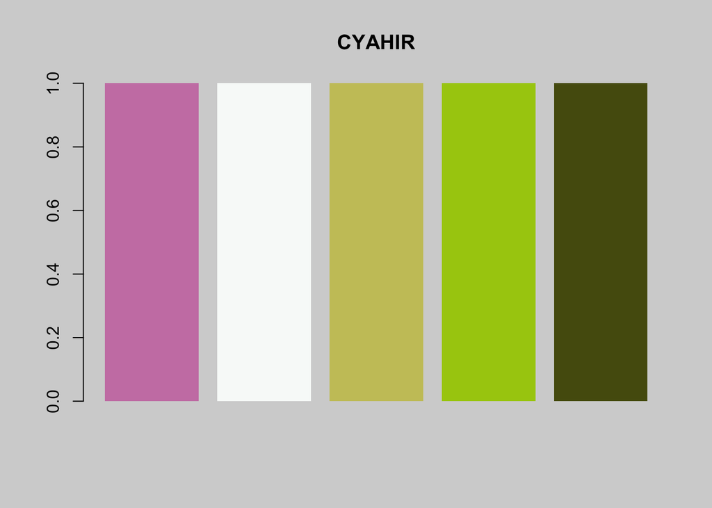

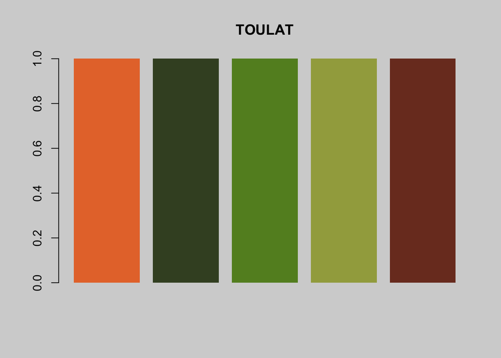

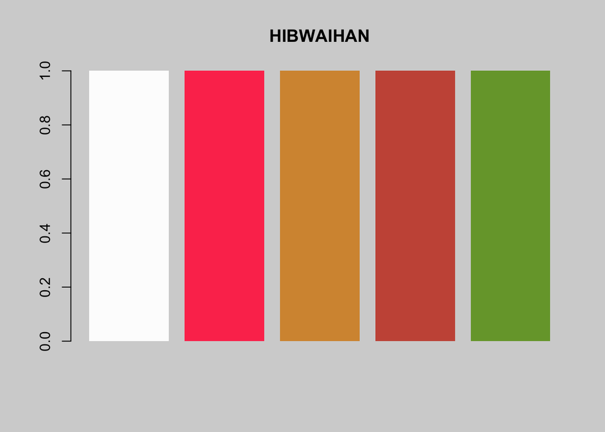

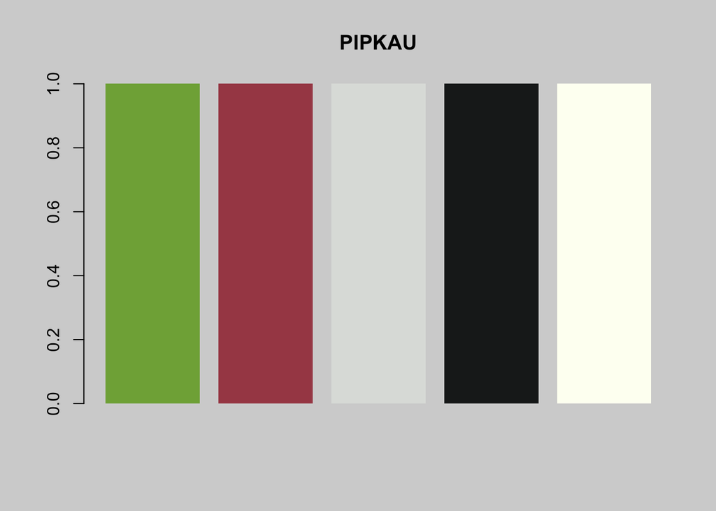

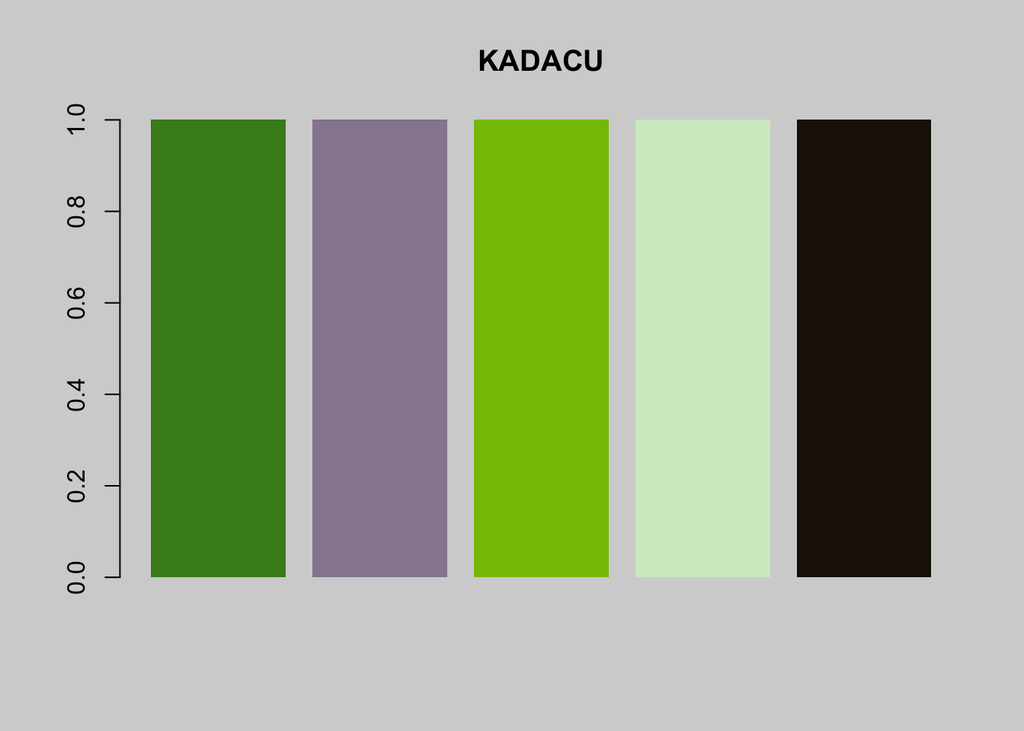

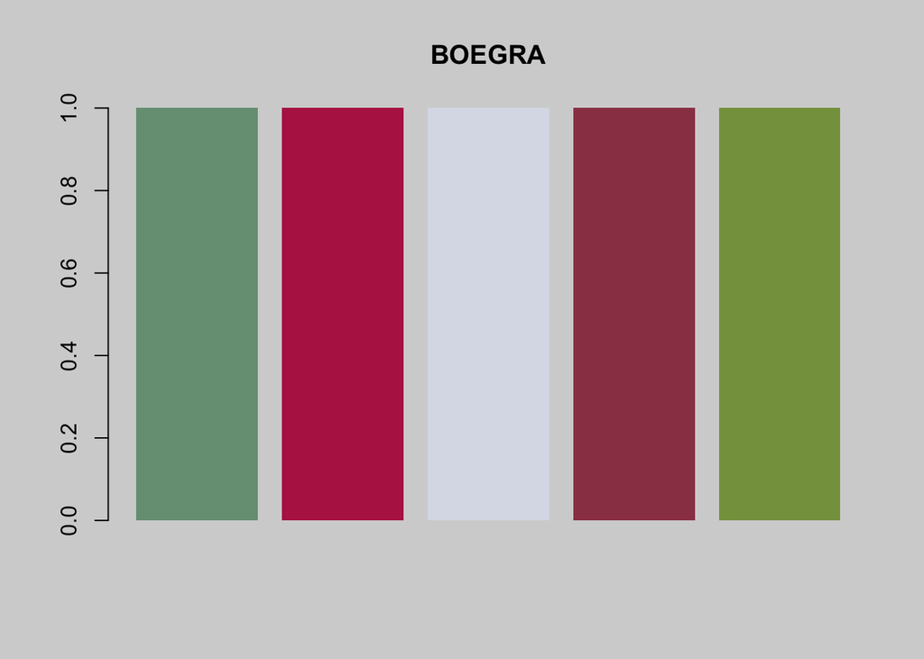

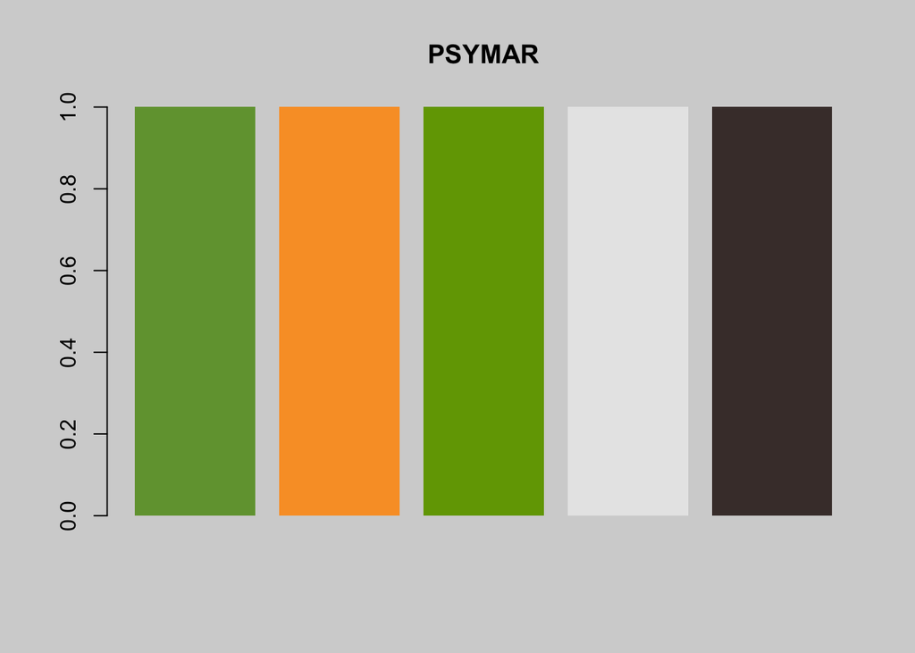

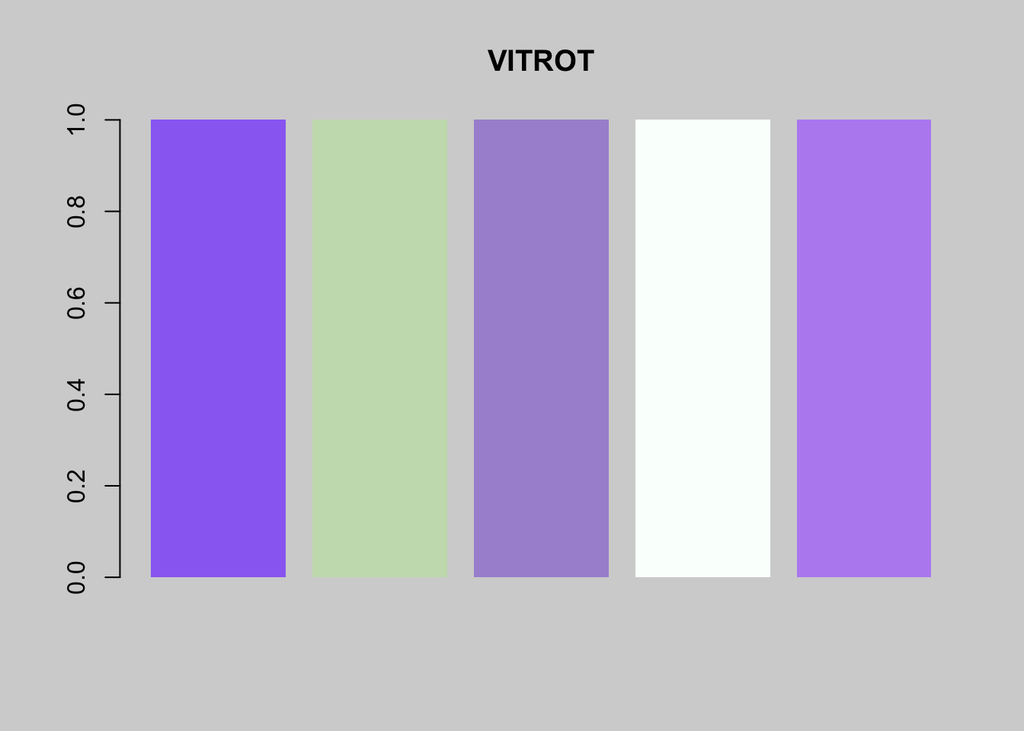

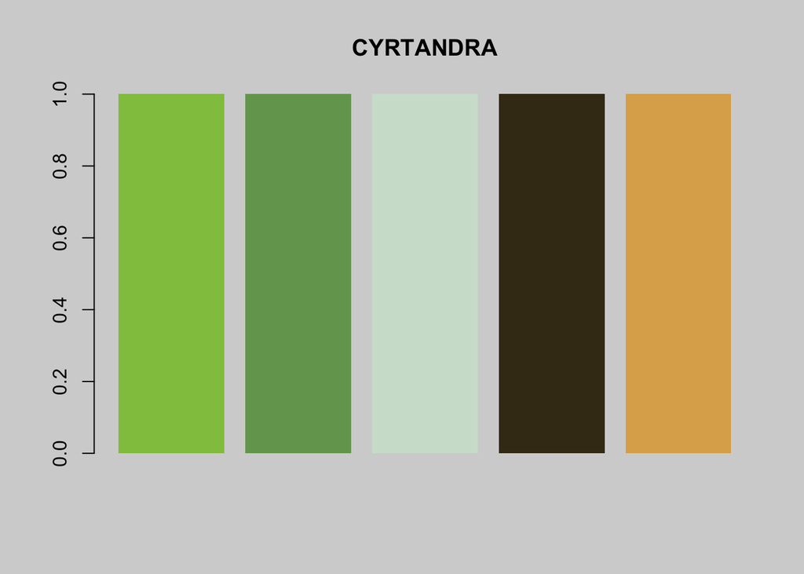

```r
example_plot <- function(palette_name) {                    ## function name = example_plot, manipulating "palette_name" variable
  colors <- plantpalette(palette_name)                      ## gets the colors of the palette you name, uses the previous function
  par(bg = "lightgray")                                     ## this just makes the background grey so it's easier to see the lighter colors
  barplot(rep(1, length(colors)),                           ## makes a barplot, with a vector of 1s with the amount of colors in the package
          col = colors,                                     ## calls the colors in the package called
          border = NA,                                      ## remove borders so it looks nicer
          main = palette_name)                              ## makes the title the plant code
}

## Test all palettes using a loop! Thankfully we just learned this! lol
## Calls a palette then loops it through the function
for (palette in names(plant_palettes)) {                    ## calls all the names in plant_palettes, loops it for each palette
  example_plot(palette)                                     ## calls the function above
}
```

### Other things you may need:

You need report any dependencies the package has from other packages. In the NAMESPACE file, you just list one those might be. This is what I put to get mine to run:

importFrom(“graphics”, “par”, “barplot”)

## Output 2 & 3: Shiny app and barplot

The barplots are pretty straightforward and uninspired, however I feel that this is the best way to showcase the survey results, and I think the color package and shiny app kinda make up for it a little.

I used old code that I made to make these barplots and readjusted them for the shiny app, which I will show below.

**Instead of showing the shiny app, I will be using markdown, so this won’t actually run.**

### Load libraries

```r
library(shiny)              # Creates interactive apps
library(tidyverse)          # Data manipulation and visualization
library(HawaiianPlantPalette)  # Custom color palette
library(patchwork)          # Combines multiple plots
library(here)               # File path management
```

### Load the dataset

```r
plant_surveys <- read_csv("data/plant_surveys.csv")
```

### Clean data

```r
plant_surveys_clean <- plant_surveys %>% ## call data
  filter(life_stage != "n/a") %>%    ## filter out any n/a's in life_stage
  filter(life_stage != "N/a") %>%    ## filter out any N/a's in life_stage (different case)
  filter(vigor != "n/a") %>%         #### filter out any n/a's in vigor
  filter(degree_surrounded != "n/a") ## filter out any n/a's in degree_surrounded
```

### Test the color palette downloaded from the package

These are the functions associated with the color package, more on this later.

```r
example_plot("KADACU")
plantpalette("TOULAT")
```

### Starting with ui –> this is the user interface and is what people will interact with.

```r
ui <- fluidPage(
  ## add title

  titlePanel("Bryophyte Associations with Vascular Plants"),

  ## add description
  p("This app allows you to see the relationship between bryophytes and vascular plants.
     You can choose to view specific plants, as well as the color package that you'd like the graph to be showcased in.
     Each plant has 5 associated colors that were extracted from photos of them. Many of the colors represent their leaves,
     fruit, flowers, bark, or other physical characteristics."),

  ## add more description
  p("The 0-4 scale represented in the graphs showcases the degree to which the bryophytes surround the vascular plant that
     was evaluated."),
  p("0 = No bryophytes present at all."),
  p("1 = Some bryophytes present, but less than 10% coverage."),
  p("2 = Bryophytes present, less than 60% coverage."),
  p("3 = Bryophytes present, around 60-90% coverage."),
  p("4 = Bryophytes present, 90-100% coverage"),

  ## make layout
  sidebarLayout(

    ## include side bar drop down panel
    sidebarPanel(

      ## select what the input will be - this is also used in the server
      selectInput(
        inputId = "species_name",

        ## name of the dropdown bar
        label = "Select a species:",

        ## choices based on data fram
        choices = c("Cyrtandra_wainihaensis", "Pipturus_kauaiensis",
                    "Touchardia_latifolia", "Boehmeria_grandis",
                    "Cyanea_spp", "Cyrtandra_confertiflora",
                    "Psychotria_mariniana",
                    "Antidesma_platyphyllum", "Hibiscus_waimeae_subsp_hannerae",
                    "Kadua_acuminata", "Charpentiera_densiflora",
                    "Cyrtandra_wawrae", "Kadua_spp"),

        ## start with this species
        selected = "Cyrtandra_wainihaensis",
        width = "100%"
      ),

      # this adds a spacer for layout
      br(),

      ## add another drop down menu
      selectInput(

         ## select what the input will be - this is also used in the server
        inputId = "color_palette",

        ## what the drop down menu says
        label = "Select a color palette:",

        ## choices based on colors available
        choices = c("CYRTANDRA", "PIPKAU", "TOULAT", "BOEGRA", "CYAHIR",
                    "PSYMAR", "HIBWAIHAN", "KADACU", "VITROT"),

        ## default selection
        selected = "CYRTANDRA",
        width = "100%"
      )
    ),

     # Main panel that will display the output
    mainPanel(
      plotOutput(outputId = "combined_plots")
    )
  )
)
```

### Moving on to the server

The code for this is pretty long, so I will just do a portion.

```r
server <- function(input, output) {

  ## render the output (this goes back to the ui where we names the output ID)
  output$combined_plots <- renderPlot({

    ## Get the selected species and color palette (this also goes back to the UI names)
    species_name <- input$species_name
    selected_palette <- input$color_palette

    ## use the color package, plantpalette is a function within the package and we just named selected_palette
    colors <- HawaiianPlantPalette::plantpalette(selected_palette)

    ## assign colors uniformly to degree_surrounded levels
    degree_levels <- c("0", "1", "2", "3", "4")

    ## setNames assigns names to a list, this eliminates a bunch of steps of having to rename per plant per category
    ## seq_along makes it so that the colors match up with the degree levels, that was a lucky coincidence that there were 5 in each category!
    color_mapping <- setNames(colors[seq_along(degree_levels)], degree_levels)

    ## Plot for All Plants
    ## get total count for all the species
    plant_surveys_all <- plant_surveys_clean %>%
      filter(species == species_name) %>%  ## filter data for selected species (matches the ui)
      group_by(degree_surrounded) %>% ## group by degree_surrounded
      summarise(total_count = n()) %>% ## get total count
      mutate(proportion = total_count / sum(total_count) * 100) %>% ## get proportion
      ungroup() ## ungroup after summarized

    all_plot <- ggplot(plant_surveys_all, aes(x = factor(degree_surrounded),  ## make ggplot, x = degreee surrounded
                                              y = proportion,                 ## y = proportion variable we made
                                              fill = factor(degree_surrounded))) + ## degree surrounded= factor bc could be mistaken for continuous variable, fill so it has different colors
      geom_bar(stat = "identity", position = "dodge", color = "black") + ## geom_bar
      geom_text(aes(label = total_count),                               ## label with total count so we know how much in each category
                position = position_dodge(width = 0.9),                 ## aesthetics
                vjust = -0.5, size = 3) +                               ## aestetics
      labs(x = "Degree Surrounded",                                    ## label
           y = "Proportion of total",
           title = paste(species_name, "All Stages")) +
      scale_fill_manual(values = color_mapping) +                       ## Apply the selected palette
      scale_x_discrete(limits = c("0", "1", "2", "3", "4")) +          ## make breaks for each category
      theme_gray() +                                                  ## grey theme so the white colors show up
      theme(legend.position = "none")                                ## no need for legen

    ## Seedlings/juveniles plot
    ## basically do the same thing but filter for non-adult life stages!
    seedlings_only <- plant_surveys_clean %>%
      filter(species == species_name, life_stage != "adult") %>% ## filter for anything that isn't an adult
      group_by(species, degree_surrounded) %>%
      summarise(total_count = n()) %>%
      mutate(proportion = total_count / sum(total_count) * 100) %>%
      ungroup()

    seedlings_plot <- ggplot(seedlings_only, aes(x = factor(degree_surrounded), y = proportion, fill = factor(degree_surrounded))) +
      geom_bar(stat = "identity", position = "dodge", color = "black") +
      geom_text(aes(label = total_count),
                position = position_dodge(width = 0.9),
                vjust = -0.5, size = 3) +
      labs(x = "Degree Surrounded",
           y = "Proportion of total",
           title = paste(species_name, "-Seedlings/Juveniles")) +
      scale_fill_manual(values = color_mapping) +
      scale_x_discrete(limits = c("0", "1", "2", "3", "4")) +
      theme_gray() +
      theme(legend.position = "none")

    ## Adults only plot
    ## do the same thing but filter for adult only life stages
    adults_only <- plant_surveys_clean %>%
      filter(species == species_name, life_stage == "adult") %>% ## filter for anything that IS adult
      group_by(species, degree_surrounded) %>%
      summarise(total_count = n()) %>%
      mutate(proportion = total_count / sum(total_count) * 100) %>%
      ungroup()

    adults_plot <- ggplot(adults_only, aes(x = factor(degree_surrounded), y = proportion, fill = factor(degree_surrounded))) +
      geom_bar(stat = "identity", position = "dodge", color = "black") +
      geom_text(aes(label = total_count),
                position = position_dodge(width = 0.9),
                vjust = -0.5, size = 3) +
      labs(x = "Degree Surrounded",
           y = "Proportion of total",
           title = paste(species_name, "-Adults")) +
      scale_fill_manual(values = color_mapping) +  # Apply the selected palette
      scale_x_discrete(limits = c("0", "1", "2", "3", "4")) +
      theme_gray() +
      theme(legend.position = "none")

    # Combine plots
    combined_plots <- wrap_plots(seedlings_plot, adults_plot, all_plot) +     ###use the patchword library to wrap all these plots together
      plot_layout(guides = "collect")            ## this actually makes the legends all combine and isn't necessary but I'm afraid if i change anything at this point that my shiny app will just collapse

    combined_plots   ## shows the combined graphs
  })
}
```

### Run the application

Woohoo!!

```r
shinyApp(ui = ui, server = server)
```

# [Completed shiny app!](https://jensenkl.shinyapps.io/Jensen_Final_Project_app/)

# [link to color package repo](https://github.com/jensen-kl/HawaiianPlantPalette)